# pml_proj.Rmd

Eric Yue

2019/3/11

## Introduction

In the course project, a large amount of data about personal activity is collected. Through wearable device, measurements about regular movement is recorded, for further quantifying how well people do some regular activity.  
The data is about 3 aspects that pertain to qualitative activity recognition: the problem of specifying correct execution, the automatic and robust detection of execution mistakes, and how to provide feedback on the quality of execution to the user.  
All of data may be classified in 5 different fashions: exactly according to the specification (Class A), throwing the elbows to the front (Class B), lifting the dumbbell only halfway (Class C), lowering the dumbbell only halfway (Class D) and throwing the hips to the front (Class E).  
The goal of this course project is to predict the manner in which enthusiasts did the exercise.

## Data cleaning and preprocession.

- The response varible  
  The train data’s summary is :

```
##     user_name    new_window  classe
##  adelmo  :3892   no :19216   A:5580
##  carlitos:3112   yes:  406   B:3797
##  charles :3536               C:3422
##  eurico  :3070               D:3216
##  jeremy  :3402               E:3607
##  pedro   :2610
```

The forecasting data’s summary is:

```
##     user_name new_window
##  adelmo  :1   no:20
##  carlitos:3
##  charles :1
##  eurico  :4
##  jeremy  :8
##  pedro   :3
```

We can find that the variables are different with 2 aspects in train data and the forecasting data. First, the difference is train data’s response variable is classe, while forecast data’s response variable is problem_id. Second, some columns in forecast data are totally NAs, while are not NAs in train data with lable “new_window”, so the train data should be transform according to forecast data.  
The question is finding a comfortable machine learning model with the train data to predict the forecast data’s “problem_id”.

- Properable variables transform  
  After look into all train variables, we find that forecasting variables doesn’t contain “yes” window, and many columns related to “new_window” containing NAs. Perhaps we have to eliminate the “yes” windows data.

There are 100 of NAs relates to “new_window” , which will be removed in model establishing process.

## Model establishing

- Split data into train and test data set

Now our data is data is ready to create the model. As first step, I will split the data into testing and training observation. The data is split into 70-30 ratio and so there are 13737 observation for training the model and 5885 observation for evaluating the model. Furthermore, there are so many variables that the column data are not comparable with in measure scale. I preprocess the data use scale with dividing by standard deviation.

Next, I will apply the elastic net regression, LDA, QDA and Random forests model on the training data.

## Classificatoin

Classification algorithm defines set of rules to identify a category or group for an observation. There is various classification algorithm available like Logistic Regression, LDA, QDA, Random Forest, SVM etc. Here I am going to use elastic net regression, LDA, QDA and Random forests.

The classification model is evaluated by confusion matrix. This matrix is represented by a table of Predicted True/False value with Actual True/False Value.

- Initial model

In order to decrease computational complexity, I will remove the highly correlated variables first.

```r
x <- trainData[, 8:59]
y <- trainData$classe
correlationMatrix <- cor(x)
highlyCorrelated <- findCorrelation(correlationMatrix, cutoff = 0.75)
name_correlated <- names(x[, highlyCorrelated])
x <- x[, -c(highlyCorrelated)]
trainData1 <- data.frame(x, y)
```

After calculating correlation matrix, I will find attributes that are highly corrected with threshhold is 0.75. All highly correlated variables are: accel_belt_z, roll_belt, accel_belt_y, accel_arm_y, total_accel_belt, accel_dumbbell_z, accel_belt_x, pitch_belt, magnet_dumbbell_x, accel_dumbbell_y, magnet_dumbbell_y, accel_dumbbell_x, accel_arm_x, accel_arm_z, magnet_arm_y, magnet_belt_z, accel_forearm_y, gyros_arm_x.

- Sample error and metrics of algorithms  
  The expected out of sample error must be considered. There are many different metrics that we can use to evaluate machine learning algorithms in R. the default metrics used are accuracy for classification problems and RMSE for regression. But Logarithmic Loss or LogLoss is more common for multi-class classification algorithms. I will use LogLoss metrics of caret to evaluate below models. AT the same time, I will use cross validation to improve the performance of algorithms.

```r
control <-
  trainControl(
  method = "cv",
  number = 10,
  classProbs = TRUE,
  summaryFunction = mnLogLoss
  )
  library(doParallel)
  num_core <- detectCores(logical = F)
  cl <- makePSOCKcluster(num_core)
  registerDoParallel(cl)
  rm(num_core)
```

- Elastic_net_regression

```r
elastic_model <-
  train(
  y ~ .,
  data = trainData1,
  method = "glmnet",
  metric = "logLoss",
  trControl = control
  )
  elastic_predictions <- predict(elastic_model, testData)
```

We get the reasonable alpha and lambda: 0.1, 3.565154810^{-4}.

```r
lda_model <- train(
  y ~ .,
  data = trainData1,
  method = "lda",
  metric = "logLoss",
  trControl = control
  )
  predi_lda <- predict(lda_model, testData)

  qda_model <- train(
  y ~ .,
  data = trainData1,
  method = "qda",
  metric = "logLoss",
  trControl = control
  )
  predi_qda <- predict(qda_model, testData)
```

- Random forests model

```r
rf_model <- train(
  y ~ .,
  data = trainData1,
  method = "rf",
  metric = "logLoss",
  trControl = control
  )
  rf_predictions <- predict(rf_model, testData)
```

- Compare the 4 models to choose best one

In order to evaluate performance of multiple machine learning algorithms, Caret provides the resamples() function where we can provide multiple machine learning models and collectively evaluate them. The results as:

```
##
## Call:
## summary.resamples(object = model_results)
##
## Models: ENM, RF, LDA, QDA
## Number of resamples: 10
##
## logLoss
##           Min.   1st Qu.    Median      Mean   3rd Qu.      Max. NA's
## ENM 1.01644958 1.0379628 1.0464965 1.0487097 1.0606403 1.0880397    0
## RF  0.09585186 0.1042106 0.1086814 0.1080761 0.1133095 0.1175689    0
## LDA 1.02055772 1.0868553 1.0878131 1.0874609 1.0988000 1.1213197    0
## QDA 0.87148272 0.9291571 0.9906152 0.9878526 1.0142205 1.1409312    0
```

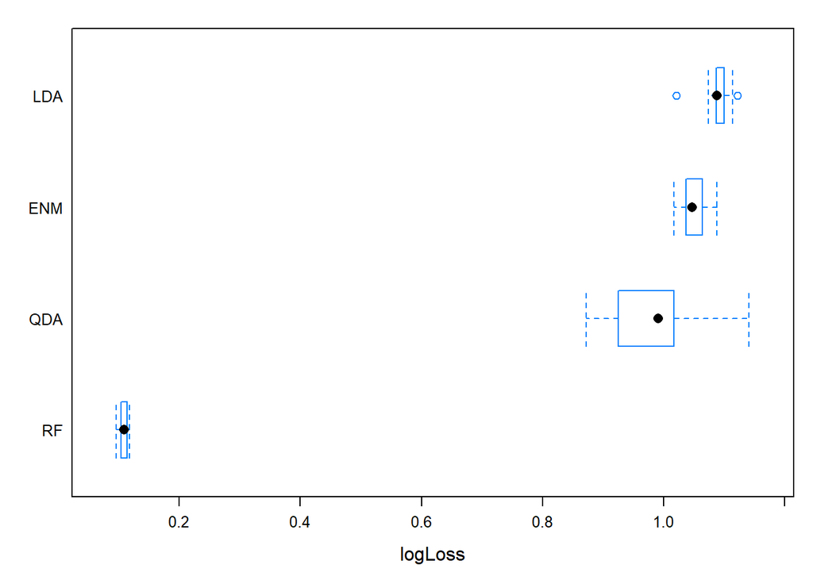

```
## Random Forest
##
## 13737 samples
##    34 predictor
##     5 classes: 'A', 'B', 'C', 'D', 'E'
##
## No pre-processing
## Resampling: Cross-Validated (10 fold)
## Summary of sample sizes: 12362, 12365, 12362, 12363, 12364, 12363, ...
## Resampling results across tuning parameters:
##
##   mtry  logLoss
##    2    0.2049254
##   18    0.1105891
##   34    0.1080761
##
## logLoss was used to select the optimal model using the smallest value.
## The final value used for the model was mtry = 34.
```

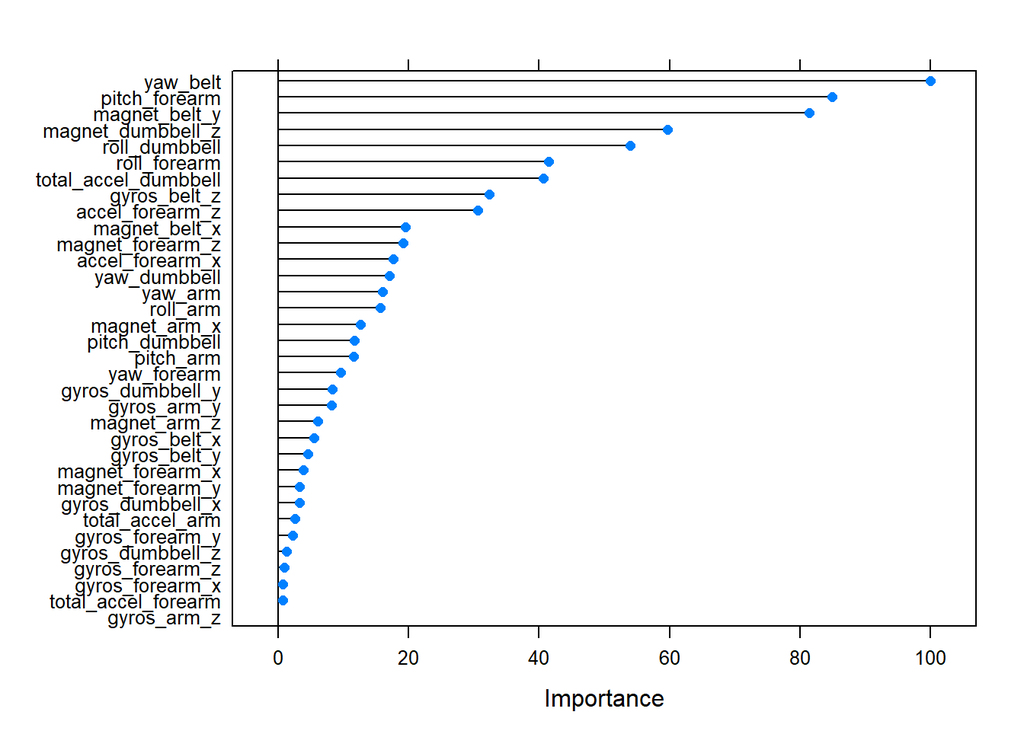

With this Random forests cross validation model, I predict the forecasting data:

```
##  [1] A A A A A C D E A A A D B A E B A B A D
## Levels: A B C D E
```

## Conclusion

In this course project, I adopted elastic net regression, LDA, QDA and Random forests model to train the personal activity data, furthermore, I use caret::resample() function to evaluate performance of multiple machine learning algorithms. The founding is Random forests are difficult to interpret but very accurate. With the Random forests algorithm, the forecasting data got the prediction:A, B, C, D, E by 11, 3, 1, 3, 2.